# Bayesian Logistic Regression models and missingness - Application in Diabetes Probability Prediction

CapStone Project_2025

Author

Namita Mishra (Advisor: Dr. Ashraf Cohen)

Published

September 23, 2025

Slides: slides.html ( Go to `slides.qmd` to edit)

## Introduction

1. **Bayesian Hierarchical Model and MCMC**

What is the goal of the paper?

To develop a Bayesian hierarchical model for multivariate longitudinal data to predict health status, trajectories, and intervention effects at the individual level in PCORI mission.

Why is it important?

Healthcare data include DNA sequences, functional images of the brain, patient-reported outcomes, and electronic health records with patients’ sequences of health measurements, diagnoses, and treatments. are complex, and the standard approaches are not adequate for clinical datasets.

How is it solved?

Use of Electronic Health Records (EHRs) with improved the diagnostic accuracy and predicts treatment effects. Visualizations of posterior distributions to help clinicians and patients to make their decision.

Combining prior knowledge and patient data with evidence predicted the patient’s health status, trajectory, and/or likely benefits of intervention. Use of Bayesian hierarchical regression on multivariate longitudinal patient data (R-packages) developed two-levels (1)time within person and (2) persons within a population along with co-variates and interventions. They combined exogenous (eg, age, clinical history) and endogenous (eg, current treatment) variables on the individual’s multivariate health measurements, with the effects of health measurements at one time on subsequent interventions.

Bayesian hierarchical model provided posterior distribution for predictor variables and an estimate of the marginal distribution of the regression coefficients for each coefficient. A large sample which is based on likelihood dominates the prior distribution for regression coefficients. Bayesian hierarchical model is a likelihood-based approach and uses priors providing sensitivities.

The integration of Markov chain Monte Carlo (MCMC) estimated the posterior distributions, and avoided missing data and complex outcome measurements.

Results and application

- Applied in pneumonia etiology (children), prostate cancer, and mental disorders to identify low-risk patient population
- To reduce the risk of over-treatment, complications,adverse effects, and financial burden for patients (Disease Reclassification).
- Prostate cancer software implementation within the hospital setup (JHM HER).

Limitation:

Models were entirely parametric, and recommended for extensions to nonparametric or more flexible parametric models for neuroimage or genomic data.

Recommendations are to address unmet need across a larger, diverse population, in other diseases (autoimmune diseases, sudden cardiac arrest, and diabetes) and to embed tools to acquire and use the most relevant information for a better outcome at an affordable cost. Zeger et al. (2020)

2. **Bayesian Inference (parametric vs non-parametric)**

What is the goal of the paper?

The study calculated the posterior probability of disease diagnosis by applying Bayesian inference to develop two modules comparing parametric (with a fixed set of parameters) and nonparametric distributions (which do not make a priori assumptions). The National Health and Nutrition Examination Survey data from two separate diagnostic tests on both diseased and non-diseased populations were used for model development.

Why is it important?

Conventional methods based on clinical criteria and fixed numerical thresholds limit the information captured on the intricate relationship between diagnostic tests and the varying prevalence of diseases. The probability distributions associated with quantitative diagnostic test outcomes have some overlap between the diseased and nondiseased groups. The dichotomous method fails to capture the complexity and heterogeneity of disease presentations across diverse populations. The applicability of the normal distribution (conventional method) is critiqued in dealing with skewness, bimodality, or multimodality.

How is it solved?

Bayesian nonparametric (vs parametric) diagnostic modeling is a Flexible distributional modeling for test outcomes; posterior disease probabilities

The study developed models using Bayesian inference for posterior probability calculation in the Wolfram Language by integrating prior probabilities of disease with distributions in both diseased and nondiseased populations. The approach enabled the evaluation of combined data from multiple diagnostic tests and resulted in improved the diagnostic accuracy, precision, and adaptability. The model showed flexibility, adaptability, and versatility in the diagnostic.

Results

Nonparametric Bayesian models were reported a better fit for data distributions given the limited existing literature, and were robust in capturing complex data patterns, producing multimodal probability patterns for disease, unlike the bimodal, double-sigmoidal curves seen with parametric models.

Limitations

- Reliance on parametric models
- Limited scholarly publications and over-dependence on prior probabilities increase the uncertainties, resulting in broader confidence intervals for posterior probabilities.
- Systemic bias (unrepresentative datasets) compromises the accuracy of Bayesian calculations.
- For Incomplete datasets, Bayesian methods combined with other statistical and computational techniques could enhance diagnostic capabilities.
- Absence of normative data compromises the reliability and validity of Bayesian diagnostic methods. Chatzimichail and Hatjimihail (2023)
3. **Bayesian methodology overview (stages, development and advantages)**

What is the goal of the paper?

The stages of Bayesian analysis are presented here specifying the importance of the priors, data modeling, inferences, model checking and refinement, selecting a proper sampling technique from a posterior distribution, variational inferences, variable selection, and its application across various research fields.

Why is it important?

Bayesian statistics is used across different fields (social sciences, ecology, genetics, medicine) where observed and unobserved parameters exist.

Variable selection- is the process of identifying the sub-set of predictors to include in a model along with determining the functional form of the model especially where a large number of potential predictors are available. Unnecessary variables in a model are associated with issues such as multicollinearity, insufficient samples, overfitting the current data leading to poor predictive performance on new data and making model interpretation more difficult.

How is it solved?

Variables selection is best after checking correlations among the variables in the model (Eg: gene-to-gene interaction to predict genes in biomedical research).

When the sample size is small, Bayesian estimation with mildly informative priors is often used. The study describes categories of priors (informative, weakly informative and diffuse) based on the degree of (un)certainty (hyperparameters) surrounding the population parameter. The prior distribution with a larger variance represents a greater amount of uncertainty surrounding. Prior elicitation through experts, generic expert, data-based, sample data using maximum likelihood or sample statistics, etc help construct a prior distribution. A prior sensitivity analysis of the likelihood - examines different forms of the model and assesses how the priors and the likelihood align and impact on posterior estimates, reflecting variations not captured by the prior or the likelihood alone. Prior estimation -allows data-informed shrinkage, regularization or influence algorithms towards a likely high-density region, and improves estimation efficiency.

In a small sample i.e. less information, incorporation of priors strengthens the observed data and lends possible value(s) for the unknown parameter(s). Knowing the exact probabilistic specification of the priors for a complex model with smaller sample sizes is important. Frequentists do not consider the probability of the unknown parameters as useful, and consider to be fixed; likelihood is considered as the the conditional probability distribution p(y|θ) of the data (y), given fixed parameters (θ).

In Bayesian inference, unknown parameters (random variables) have varied values, while the (observed) data have fixed values. The likelihood is a function of θ for the fixed data y. Therefore, the likelihood function summarizes a statistical model that stochastically generates a range of possible values for θ and the observed data y. With priors and the likelihood of the observed data, the resulting posterior distribution provides an estimate of the unknown parameters, capture primary factors to improve our understanding. Monte Carlo technique provides integrals of sampled values from a given distribution through computer simulations. The packages BRMS and Blavaan in R are used for the probabilistic programming language Stan. MCMC algorithm only requires the probability distribution of interest to be specified up to a constant of proportionality and is scalable to high dimensions to obtain empirical estimates of the posterior distribution of interest. Bayesian inference adopts a simulation-based strategy for approximating posterior distributions.

Spatial and temporal variability are factored in Bayesian general linear models. A posterior distribution can simulate new data conditional on this distribution and assess, to providing valid predictions.

Results and application

The Bayesian approach analyzes large-scale cancer genomic data, identifies novel molecular changes in cancer initiation and progression, the interactions between mutated genes and captured mutational signatures, highlighting key genetic interactions components, allowing genomic-based patient stratification both in clinical trials, in the personalized use of therapeutics, and in understanding cancer and its evolutionary processes.

The study proposes strategies for reproducibility and reporting standards, outlining a checklist and emphasize on the impact of Bayesian analysis on artificial intelligence in the future.

Limitations

In temporal models, the spatial and/or temporal dependencies (autocorrelation of parameters over time)is a challenge in posterior inference.The subjectivity of priors is highlighted by critics as a potential drawback of Bayesian methods. Schoot et al. (2021)

4. **Bayesian Normal linear regression, Core parametric (conjugate) model with Normal–Inverse-Gamma prior**

What is the goal of the paper?

The study emphasizes prior elicitation, analytical posteriors, robustness checks through guidance provided on Bayesian inference by performing Bayesian Normal linear regression in metrology to calibrate instruments to evaluate inter-laboratory comparisons in determining fundamental constants.

Why is it important?

Errors are **independent and identically distributed in Gaussian** and variance is unknown and is estimated from data, the relationship between X and Y is statistical, with noise and model uncertainty and the regression can not be treated as a measurement function . There is a need for statistical approaches (likelihood, Bayesian, bootstrap, etc.) to quantify uncertainty Guide to the Expression of Uncertainty in Measurement (GUM) and its supplements are not applicable directly.

How is it solved?

Bayesian inference accounts for a priori information, and robustifies the analyses. It emphasizes steps (prior elicitation, posterior calculation, and robustness to prior uncertainty and model adequacy) for the model development and about assumptions critical to Bayesian inference.

All unknowns (observables (data) and unobservables such as parameters and auxiliary variables) are considered random, are assigned probability distributions of the available information, and update prior knowledge about the unobservables with information about them contained in the data. The graphical representation of prior distribution and likelihood function, sensitivity analyses, or model checking enhances the elicitation and interpretation process.

For Normal linear regression problems (1) prior distribution - Normal inverse Gamma (NIG) distribution to a posterior is from the same family of (NIG) distribution. The NIG prior with known variance σ2 of observations is a conjugate prior distribution. Vague or non-informative prior distributions can be derived from NIG prior. (2) alternative families of prior distributions (hierarchical priors) assign an additional layer of distributions to uncertain prior parameters or non-parametricriors.

Bayesian inference is influenced by

- the uncertainty in the transformation of prior knowledge to prior distributions

- the assumptions of the statistical model

- the mistakes in data acquisition

Results and Application

The knowledge from related previous experiments (Normal inverse Gamma distributions) allows for analytic posterior calculations of many quantities of interest. Klauenberg et al. (2015)

5. **Bayesian Hierarchical / meta-analytic linear regression and priors (exchangeable and unexchangeable)**

What is the goal of the paper?

The study developed a test of a formal method for augmenting data in linear regression analyses, by incorporating both exchangeable and unexchangeable information on regression coefficients (and standard errors) of previous studies.

Why is it important?

The frequent combination of multiple testing has relatively low statistical power, which is problematic in null-hypothesis significance testing. Linear regression analyses do not account for the published results and summary statistics from similar previous studies. Ignoring information on parameters from previous studies (relevant and readily available), affects the stability and precision of the parameter estimates resulting in lower values than they could have been, resulting in conclusions that are less certain and are affected by sampling variation.

Multiple linear regression with separate significance tests for all regression coefficients, and with the modest sample sizes, different studies have different sets of statistically significant predictors, and addressing the issue on larger samples is practically unrealistic.

How is it solved?

Bayesian linear regression accommodates prior knowledge. To overcome the absence of formal studies, it handles the issue of increasing the sample size, and augments the data of a new study with regression coefficients and standard errors from previous similar studies.

To solve the issue of the univariate case analysis, Bayesian linear regression combines the evidence of specific predictors from different linear regression analyses (meta-analysis) to resolve the issue of simultaneously combining multiple regression parameters per study, which ignore the relationship between the regression coefficients.

Adding summary statistics from previous studies in Bayesian linear regression provide a more acceptable solution esp. when previous study data are not (realistically) obtainable.

Based on the information of predictors from previous and current data, the models are categorized into (1) Exchangable - when the current data and previous studies have the same set of predictors. (2) Unexchangable – when the predictors were different in the two.

The steps to Bayesian linear regression steps are mentioned here that yield the posterior density reflecting the updated knowledge about the model parameters after having observed the data,

1. To calculate the probability density function for the data, given the unknown model parameters;
2. The likelihood function - that quantifies what is assumed to be known about the model parameters before observing the data. The Standard multiple linear regression model, integrate the prior, and provide the joint posterior density using the Gibbs sampler.
3. A hierarchical model version is used to analyze parameters where studies are under not-exchangeable category.

Results

Incorporating priors in a linear regression on new data yield a significantly better parameter estimate with an adequate approximation. Encouraging performance gains and the large effects are obtained when the data from previous studies are incorporated. Performance of the two versions (exchangeable and unexchangeable) of the replication model was consistently superior to using the current data alone. The model using exchangeable and unexchangeable prior offers better parameter estimates in a linear regression setting without the need to expend a large amount of time and energy to obtain data from the previous studies.

Hierarchical unexchangeable model version offers the advantage of being able to address questions about differences between studies and thus allows for explicit testing of the exchangeability assumption.

Limitations

- All studies need to have the same set of predictors.
- The issue of correlation between predictor variables. Leeuw and Klugkist (2012)
6. **Bayesian logistic regression (Bayesian GLM) (Sequential clinical reasoning approach)**

What is the goal of the paper?

To study was conducted on a longitudinal prospective cohort to develop a model to predict the risk of incident cardiovascular disease. They incorporated (1) demographic features (basic) (2) six metabolic syndrome components (metabolic score) (3) conventional risk factors (enhanced model)

The application of Logistic Regression included priors on coefficients and sequential updating to predict Individual-level CVD risk.

Why is it important?

Early diagnosis of at risk population (CVD), impacts health interventions. Limited availability of molecular information in clinical practice (high cost and unavailability) affects efficient disease diagnosis.

It is required to have an alternative approach to analyze data to efficiently identify a high-risk population based on the routinely checked biological markers before doing these expensive molecular tests.

The tailored Framingham Risk Score method, is not sufficient because of the differences present in ethnic groups, location, and socio-economic status, and require the construction of their own models. Heterogeneity (geographic, ethnic group, variations, and different characteristics of social contextual network) often is unobservable and unmeasurable.

How is it solved?

The subjects enrolled in a screening program (Keelung Community) for mass screening (20–79 years) in the Keelung city of Taiwan, were analyzed for 5 years to identify incident cancers and chronic diseases (cardiovascular disease).

The study was able to classify the risk of having incident CVD cases by (1) available and calculated standardized risk score of the MetS components (fasting glucose, blood pressure, HDL-C, triglyceride and waist circumference) (2) together with conventional risk factors (gender, heredity, smoking, alcohol drinking, family history of parent’s CVD and betel quid and other factors).

Emulating a clinician’s evaluation process, the Bayesian clinical reasoning approach in a sequential manner was developed and applied in three models.

The Bayesian clinical reasoning approach considered the normal distribution of regression coefficients of all predictors, allowing for uncertainty of clinical weights. The credible intervals of predicted risk estimates were obtained by averaging out. In the model, the individual risk is elicited by prior speculation (first impression) that is updated by objective observed data (patient’s history and laboratory findings), the regression coefficients for computing risk score were treated as random variable with a certain statistical distribution (e.g. normal distribution) rather than a fixed value (traditional risk prediction model by frequentist). The updated prior distribution with the likelihood of the current data provided a posterior distribution to predict the risk for a specific disease. The sequential approach included -

1. Basic model developed via logistic regression used prior information constructed on gender, age, age2, and time period.
2. The Classical model (metabolic score model: MS model) included six MetS components.
3. The third (enhanced model) incorporated information on smoking, drinking, betel-quid, and family history of CVD.

Results

Compared to the basic model and classical model, the enhanced model had better performance. The proposed models predicted CVD incidence at the individual level by incorporating routine information with a sequential Bayesian clinical reasoning approach. Patients’ background significantly contributes to baseline risk. Even with ecological heterogeneity, the regression model adopts individual characteristics and makes individual risk prediction for the CVD incidence.

Limitations

- Whether the interactions between age, gender, metabolic score, and other risk factors should be included.
- The use of an enhanced model should be validated through external validation by applying the proposed models to new subjects not included in the training of the model parameters. Liu et al. (2013)
7. **Bayesian parameter estimation in discrete Weibull regression**

What is the goal of the paper?

The study provided the Bayesian approach for parameter estimation in discrete Weibull regression conditioned on the predictors under a uniform non-informative prior, to produce posterior distribution. The model promises its wide applicability to analyze count data using R package BDWreg.

Why is it important?

Discrete data (eg: quality of care, planning capacity within a hospital, the number of visits to a specialist and genomic data) are often highly-skewed distributions.

How is it solved?

Similarly to Weibull regression for lifetime data analysis and survival analysis for continuous response variables, a regression model for a discrete variable based on the discrete Weibull distribution report a good fit in comparison with other distributions for count data.

Features of discrete Weibull distribution such as -Poissonmixtures, -Poisson-Tweedie, -zero-inflated semi-parametric regression and -COMPoisson -the ability to capture both over and under-dispersion and a closed-form analytical expression of the quantiles of the conditional distribution make it an alternative to the more traditional Poisson and Negative Binomial distributions.

Non-informative priors and the Laplace priors with a hyper penalty parameter calculated posterior distribution which is proper with finite moments under a uniform non-informative prior.

Results

The advantage of Bayesian approaches over classical maximum likelihood inference are: (1) the possibility of taking prior information into account, such as sparsity or information from historical data, (2) the procedure returns automatically the distribution of all parameters, from which credible intervals can easily be obtained.

Application

8.Bayesian Multiple Imputation and Logistic regression

Missing data, common occurrence in clinical research occurs when the values of the variables of interest are not measured or recorded for all subjects in the sample due to - (i) patient refusal to respond to specific questions (ii) loss of patient to follow-up; (iii)investigator or mechanical error (iv) physicians not ordering certain investigations for some patients

The study mention the importance of understanding the type of missing data (MAR, MNAR, MCAR), based on the type missing data, Multiple imputation (MI) is a popular approach for addressing the presence of missing data. Mi provides multiple plausible values of a given variable imputed or filled in for each subject who has missing data for that variable. This results in the creation of multiple completed data sets.

With this approach identical statistical analyses are conducted in each of these complete data sets. The pooled results from across complete data sets, are then analyzed.

The study introduces MI, its implementation, developing the imputation model, emphasizing number of imputed data sets to create, and addresses derived variables.

They provided application of MI through an analysis on patients hospitalized with heart failure to estimate the probability of 1-year mortality in the presence of missing data using (R, SAS, and Stata)Austin et al. (2021)

## Method and Data Preparation

Statistical Tool used is R, R packages, and libraries to import data, management and conduct analysis. Using haven package .XPT files were converted to R-object as dataframe (df).

Data Source - The retrospective study used NHANES 2-year cross-sectional data (between 2013-2014 year) extracted from 3 datasets (demographics, exam, questionnaire) Center for Health Statistics (1999).

Data Management

We created subsets from original 3 datasets (demographics, exam, questionnaire) with selected variables of interest and then merged ininto a single dataframes for analysis and data exploration. The merged dataframe was cleaned, categorized, and recoded and analyzed for basic statistics, anamolies and patterns before running Bayesian regression. Final dataset included weighted means of all selected variables of interest -

1. Response Variable (Binary, Diabetes) was defined as - “Is there one Dr you see for diabetes”
2. Predictor Variables (Body Mass Index, factor, 4 levels)

```r
install.packages("gt")
library(gt)

variables <- c("SEQN", "BMDBMIC", "RIDAGEYR", "RIAGENDR", "RIDRETH1",
               "SDMVPSU", "SDMVSTRA", "WTMEC2YR", "DIQ240")



df <- data.frame(Variable = variables, Description = descriptions <- c("Respondent sequence number",
        "BMI calculated as weight in kilograms divided by height in meters squared, and then rounded to one decimal place.",
                  "Age Age in years of the participant at the time of screening. Individuals 80 and over are topcoded at 80 years of age.",
                  "Gender",
                  "Race/ethnicity Recode of reported race and Hispanic origin information",
                  "Sample PSU",
                  "Sample strata",
                  "MEC exam weight",
                  "Diabetes status Is there one doctor or other health professional {you usually see/SP usually sees} for {your/his/her} diabetes? Do not include specialists to whom {you have/SP has} been referred such as diabetes educators, dieticians or foot and eye doctors."))
df %>%
  gt %>%
  tab_header(
    title = "Table Variable Description"
  ) %>%
  tab_footnote(
    footnote = "Each variable in the dataset, accompanied by a qualitative description from the study team."
  )
```

Table Variable Description

| Variable | Description |
| --- | --- |
| SEQN | Respondent sequence number |
| BMDBMIC | BMI calculated as weight in kilograms divided by height in meters squared, and then rounded to one decimal place. |
| RIDAGEYR | Age Age in years of the participant at the time of screening. Individuals 80 and over are topcoded at 80 years of age. |
| RIAGENDR | Gender |
| RIDRETH1 | Race/ethnicity Recode of reported race and Hispanic origin information |
| SDMVPSU | Sample PSU |
| SDMVSTRA | Sample strata |
| WTMEC2YR | MEC exam weight |
| DIQ240 | Diabetes status Is there one doctor or other health professional {you usually see/SP usually sees} for {your/his/her} diabetes? Do not include specialists to whom {you have/SP has} been referred such … |

Each variable in the dataset, accompanied by a qualitative description from the study team.

Weighted means and sd extracted from the datasets using library(survey) are reported and the final merged dataframe included 9813 observations.

The unique categories, level, special codes and NAs of each variables were explored.

```r
library(DataExplorer)

str(merged_data)
```

```
'data.frame':   9813 obs. of  9 variables:
 $ SEQN    : num  73557 73558 73559 73560 73561 ...
 $ BMDBMIC : Factor w/ 4 levels "Underweight",..: NA NA NA 2 NA NA NA NA NA NA ...
 $ RIDAGEYR: num  69 54 72 9 73 56 0 61 56 65 ...
 $ RIAGENDR: Factor w/ 2 levels "Male","Female": 1 1 1 1 2 1 1 2 2 1 ...
 $ RIDRETH1: Factor w/ 5 levels "Mexican American",..: 4 3 3 3 3 1 3 3 3 3 ...
 $ SDMVPSU : num  1 1 1 2 2 1 1 1 1 2 ...
 $ SDMVSTRA: num  112 108 109 109 116 111 105 114 112 112 ...
 $ WTMEC2YR: num  13481 24472 57193 55767 65542 ...
 $ DIQ240  : Factor w/ 2 levels "Yes","No": 1 1 2 NA NA NA NA NA NA NA ...
```

```r
plot_str(merged_data)
introduce(merged_data)
```

```
  rows columns discrete_columns continuous_columns all_missing_columns
1 9813       9                4                  5                   0
  total_missing_values complete_rows total_observations memory_usage
1                15381            14              88317       554936
```

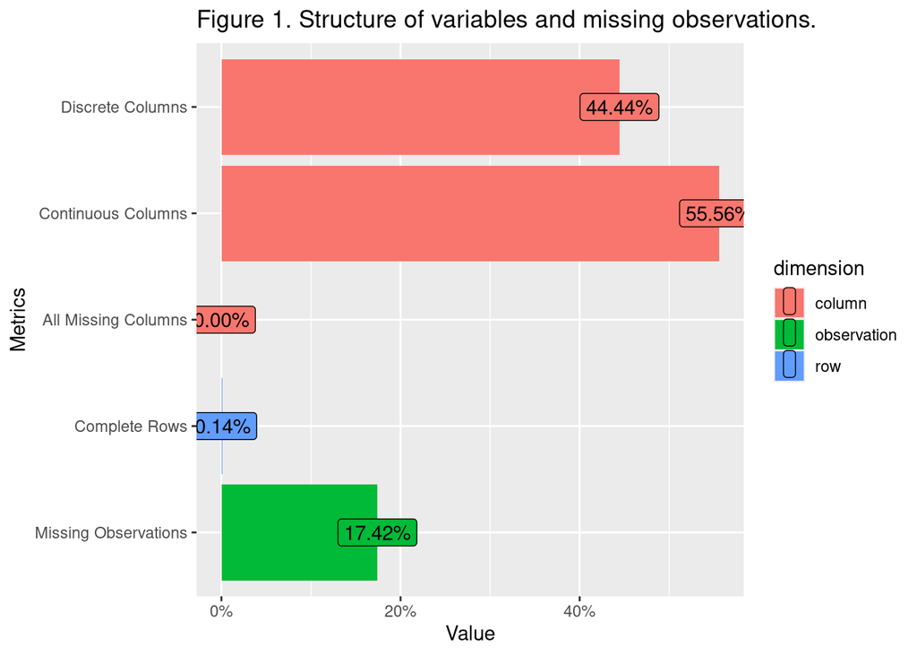

```r
plot_intro(merged_data, title="Figure 1. Structure of variables and missing observations.")
```

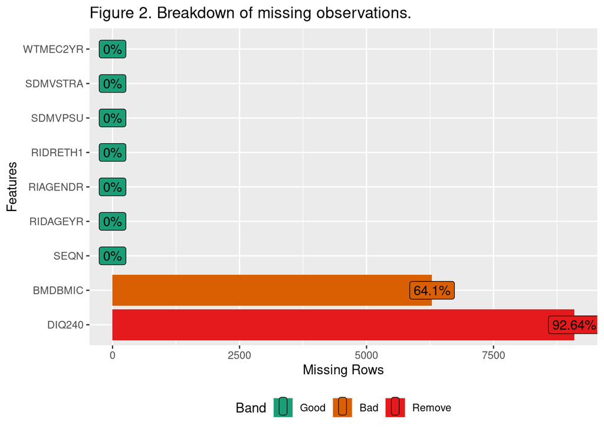

```r
plot_missing(merged_data, title="Figure 2. Breakdown of missing observations.")
```

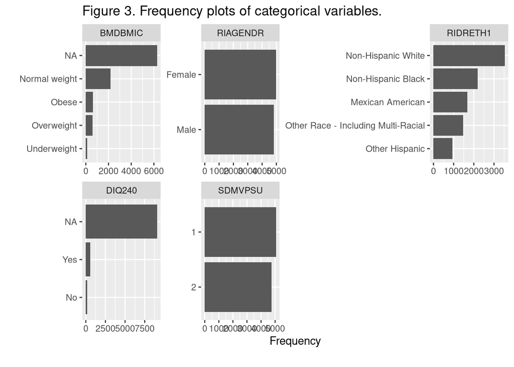

```r
plot_bar(merged_data, title = "Figure 3. Frequency plots of categorical variables.")
```

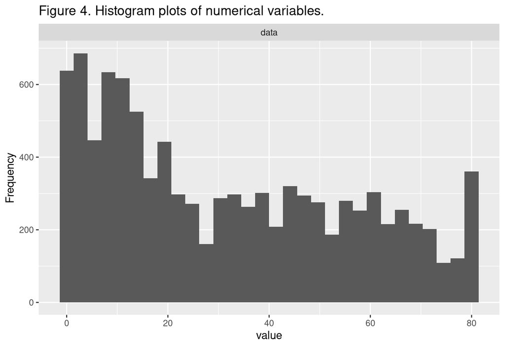

```r
plot_histogram(merged_data$RIDAGEYR, title = "Figure 4. Histogram plots of numerical variables.")
```

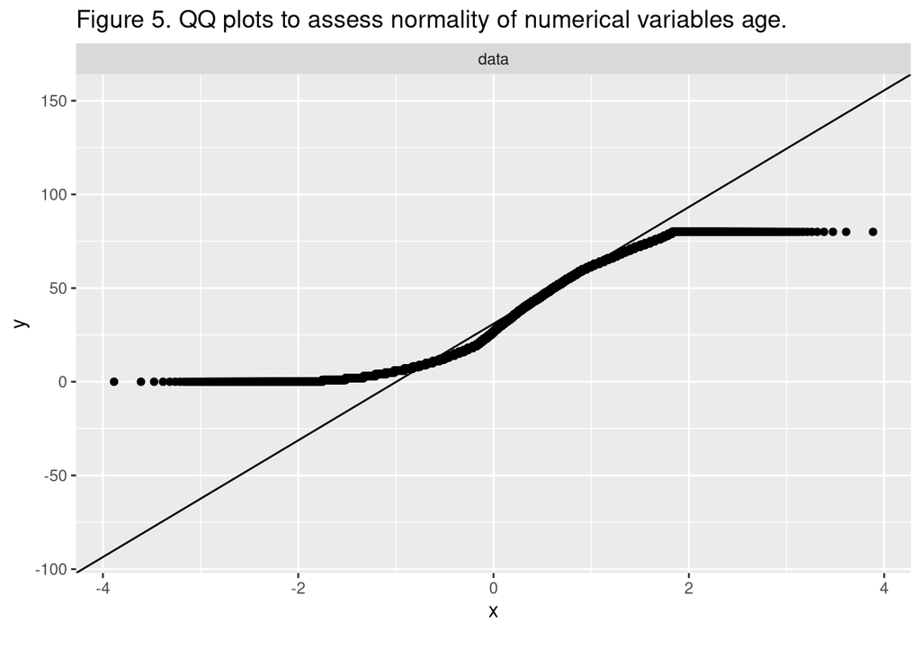

```r
plot_qq(merged_data$RIDAGEYR, title = "Figure 5. QQ plots to assess normality of numerical variables age.")
```

## Explain your data preprocessing and cleaning steps.

Data Cleaning of the merged dataset revealed missing values (NA), special codes (7,9,77,99). Considering special codes are not random and cannot be dropped, based on the variable (codebook) they were transformed into NAs. All NAs were included in the analysis, since R automatically excludes rows with NA via listwise deletion or complete case analysis during regression.

To explore missigness in the data, we conducted linear regression lm (), and listwise deletion of rows resulted in a reduced sample size (n=14), which could introduce bias as the informative missingness if ignored (MAR or MNAR). The regression resulted in quasi-separation (warning).

## Raw Data Exploration and Visualization

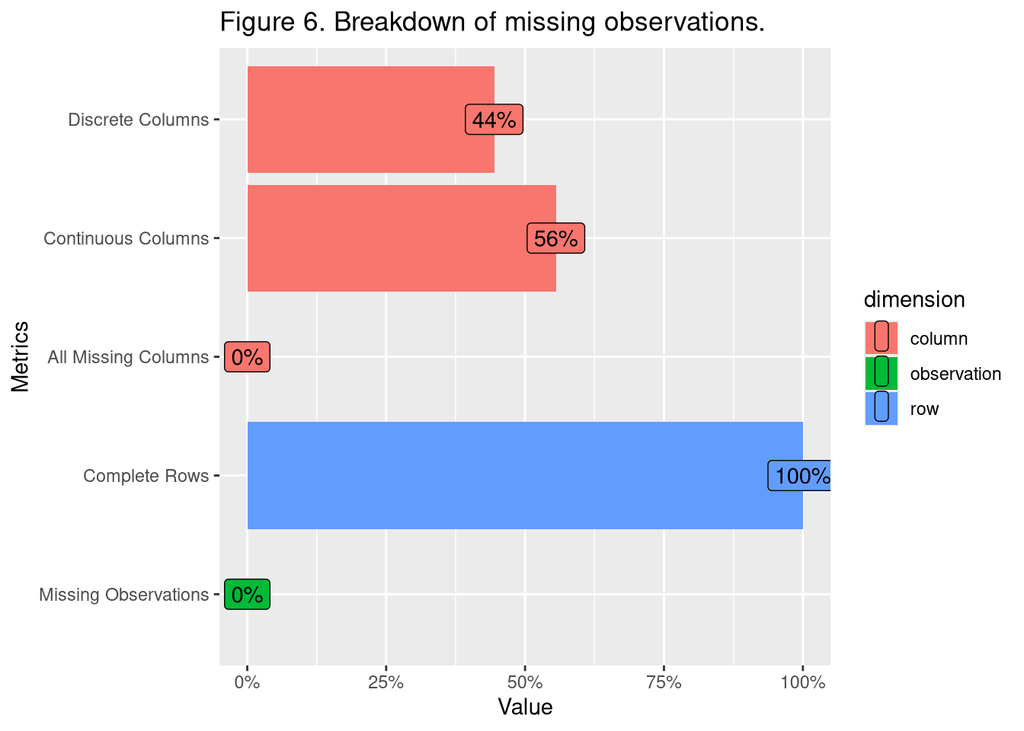

```r
plot_intro(clean_data, title="Figure 6. Breakdown of missing observations.")
```

The graph shows the data after removing all the NAs.

```r
# Count NAs in all columns

colSums(is.na(merged_data))
```

```
    SEQN  BMDBMIC RIDAGEYR RIAGENDR RIDRETH1  SDMVPSU SDMVSTRA WTMEC2YR
       0     6290        0        0        0        0        0        0
  DIQ240
    9091
```

```r
colSums(is.na(clean_data))
```

```
    SEQN  BMDBMIC RIDAGEYR RIAGENDR RIDRETH1  SDMVPSU SDMVSTRA WTMEC2YR
       0        0        0        0        0        0        0        0
  DIQ240
       0
```

We then recoded variables in the merged data, special codes were included in NA category and the descriptive summary statistics presented in tabulated form for continuous and categorical variables include counts, frequencies, proportions mean and sd

```r
# corss-tabulation #

table(merged_data$diab, merged_data$BMI_cat,useNA="ifany")
```

```
       Underweight Normal weight Overweight Obese <NA>
  Yes            0             5          3     2  543
  No             0             2          2     0  165
  <NA>         132          2160        590   627 5582
```

```r
table(merged_data$race, merged_data$diab, useNA="ifany") # before cleaning and imputation
```

```
                                       Yes   No <NA>
  Mexican American                      86   41 1558
  Other Hispanic                        48   15  867
  Non-Hispanic White                   206   56 3276
  Non-Hispanic Black                   146   36 2016
  Other Race - Including Multi-Racial   67   21 1374
```

```r
table(merged_data$gender, merged_data$diab, useNA="ifany")
```

```
          Yes   No <NA>
  Male    264   87 4480
  Female  289   82 4611
```

```r
# Print with title
kable(final_table, caption = "Table 1. Descriptive Statistics of Study Variables")
```

Table 1. Descriptive Statistics of Study Variables

| Variable | Category | Count | Proportion | Mean | SD | Min | Max |
| --- | --- | --- | --- | --- | --- | --- | --- |
| Diabetes Status | Yes | 553 | 0.056 | NA | NA | NA | NA |
| Diabetes Status | No | 169 | 0.017 | NA | NA | NA | NA |
| Diabetes Status | NA | 9091 | 0.926 | NA | NA | NA | NA |
| Age | NA | NA | NA | 31.62957 | 24.39755 | 0 | 80 |
| Gender | Male | 4831 | 0.492 | NA | NA | NA | NA |
| Gender | Female | 4982 | 0.508 | NA | NA | NA | NA |
| BMI Category | Underweight | 132 | 0.013 | NA | NA | NA | NA |
| BMI Category | Normal weight | 2167 | 0.221 | NA | NA | NA | NA |
| BMI Category | Overweight | 595 | 0.061 | NA | NA | NA | NA |
| BMI Category | Obese | 629 | 0.064 | NA | NA | NA | NA |
| BMI Category | NA | 6290 | 0.641 | NA | NA | NA | NA |
| Race | Mexican American | 1685 | 0.172 | NA | NA | NA | NA |
| Race | Other Hispanic | 930 | 0.095 | NA | NA | NA | NA |
| Race | Non-Hispanic White | 3538 | 0.361 | NA | NA | NA | NA |
| Race | Non-Hispanic Black | 2198 | 0.224 | NA | NA | NA | NA |
| Race | Other Race - Including Multi-Racial | 1462 | 0.149 | NA | NA | NA | NA |

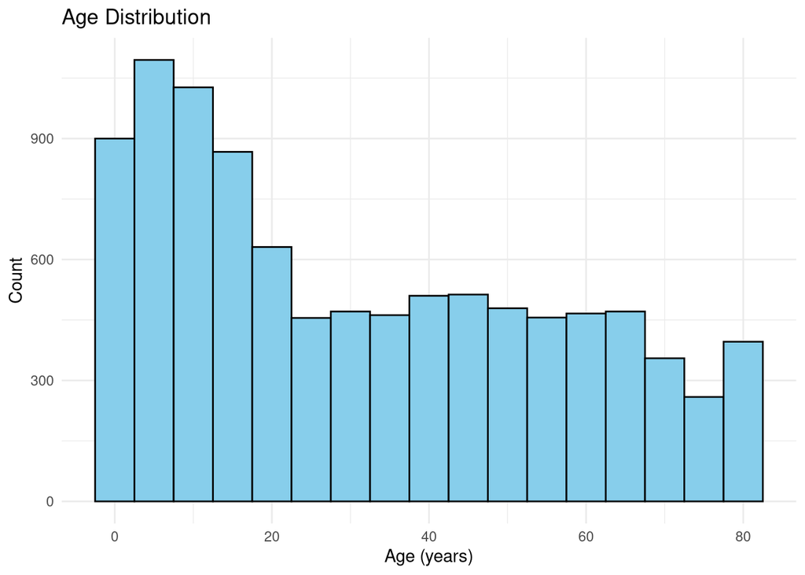

```r
# load a libraries
library(knitr) # fancy table
library(tidyverse) # load library tidyverse
library(classpackage)
library(ggplot2)
library(dplyr)



# Age distribution
ggplot(merged_data, aes(x = age)) +
  geom_histogram(binwidth = 5, fill = "skyblue", color = "black") +
  theme_minimal() +
  labs(title = "Age Distribution", x = "Age (years)", y = "Count")
```

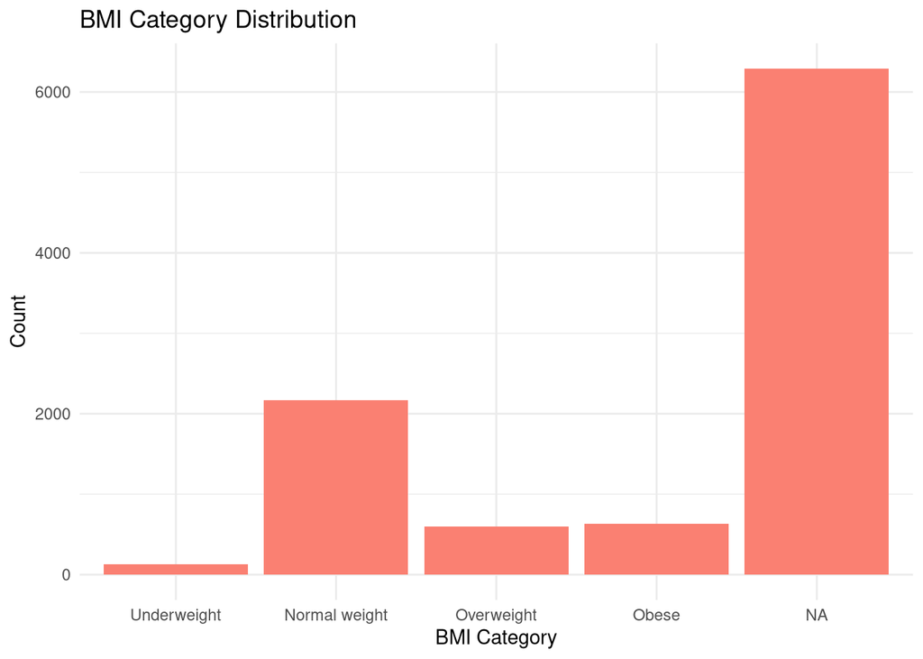

```r
# BMI category
ggplot(merged_data, aes(x = BMI_cat)) +
  geom_bar(fill = "salmon") +
  theme_minimal() +
  labs(title = "BMI Category Distribution", x = "BMI Category", y = "Count")
```

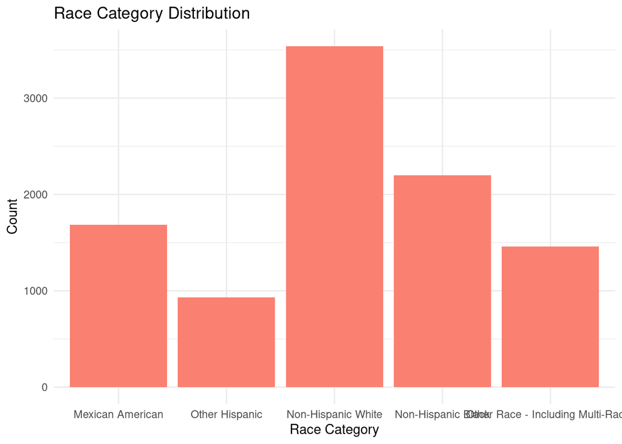

```r
# Race category
ggplot(merged_data, aes(x = race)) +
  geom_bar(fill = "salmon") +
  theme_minimal() +
  labs(title = "Race Category Distribution", x = "Race Category", y = "Count")
```

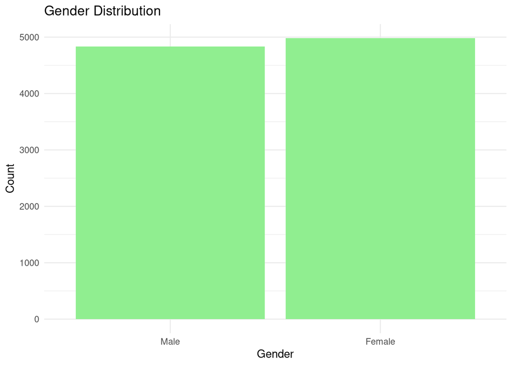

```r
# Gender
ggplot(merged_data, aes(x = gender)) +
  geom_bar(fill = "lightgreen") +
  theme_minimal() +
  labs(title = "Gender Distribution", x = "Gender", y = "Count")
```

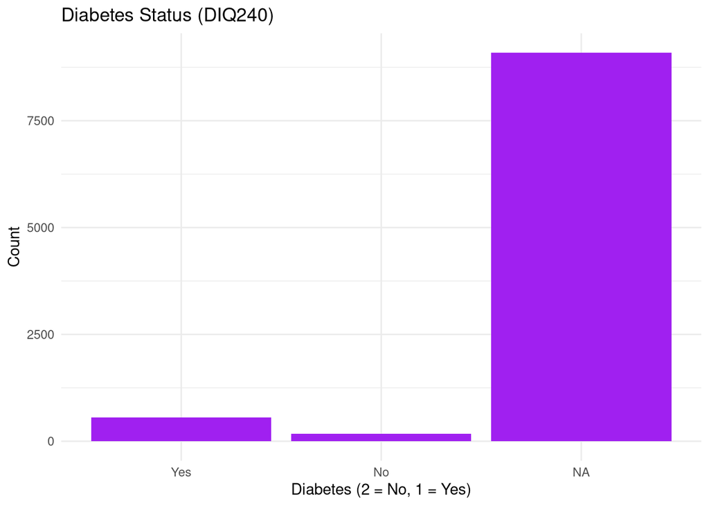

```r
# Outcome
ggplot(merged_data, aes(x = factor(diab))) +
  geom_bar(fill = "purple") +
  theme_minimal() +
  labs(title = "Diabetes Status (DIQ240)", x = "Diabetes (2 = No, 1 = Yes)", y = "Count")
```

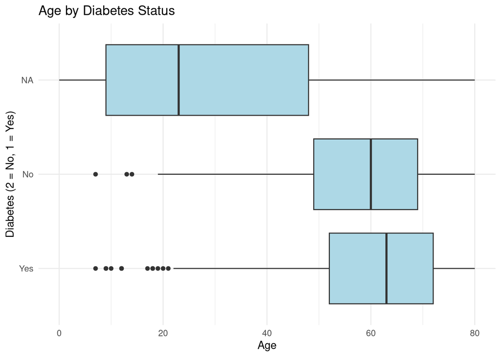

```r
# Cross - tabulation #

# DIQ240 by Age #
ggplot(merged_data, aes(x = age , y = factor(diab))) +
  geom_boxplot(fill = "lightblue") +
  theme_minimal() +
  labs(title = "Age by Diabetes Status", x = "Age", y = "Diabetes (2 = No, 1 = Yes)" )
```

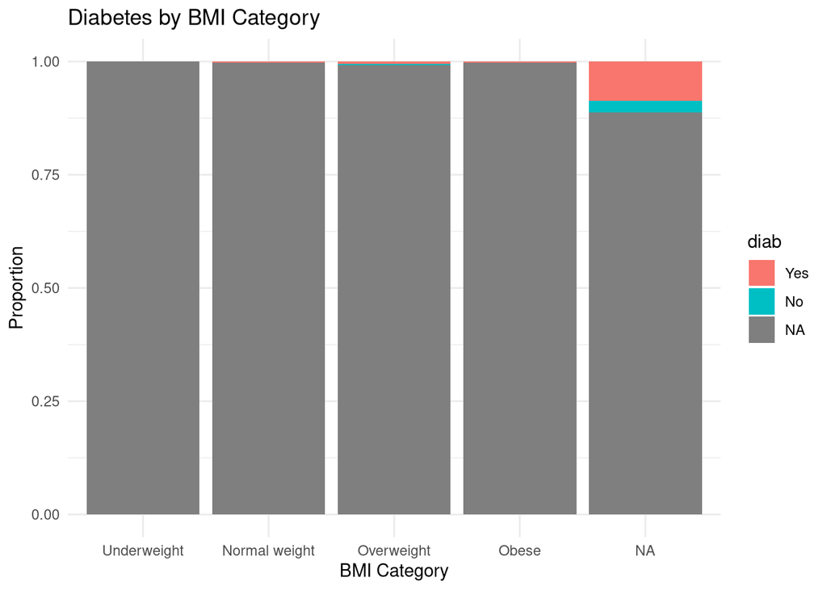

```r
#  DIQ240 by BMI  #

## ALL NAs ##
ggplot(merged_data, aes(x = BMI_cat  , fill = factor(diab))) +
  geom_bar(position = "fill") +
  theme_minimal() +
  labs(title = "Diabetes by BMI Category", x = "BMI Category", y = "Proportion", fill = "diab")
```

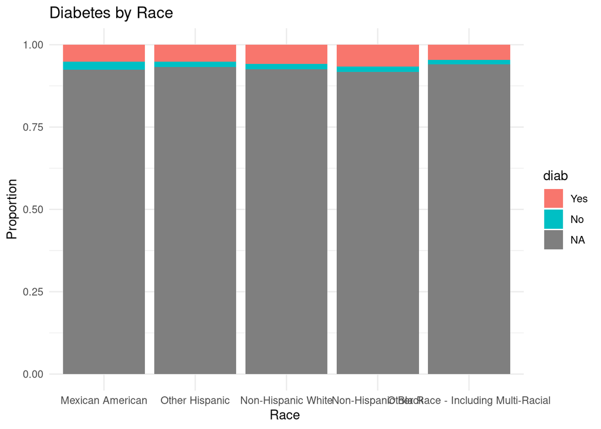

```r
# DIQ240 by Race  #
ggplot(merged_data, aes(x = race, fill = factor(diab)  )) +
  geom_bar(position = "fill") +
  theme_minimal() +
  labs(title = "Diabetes by Race ", x = "Race ", y = "Proportion", fill = "diab")
```

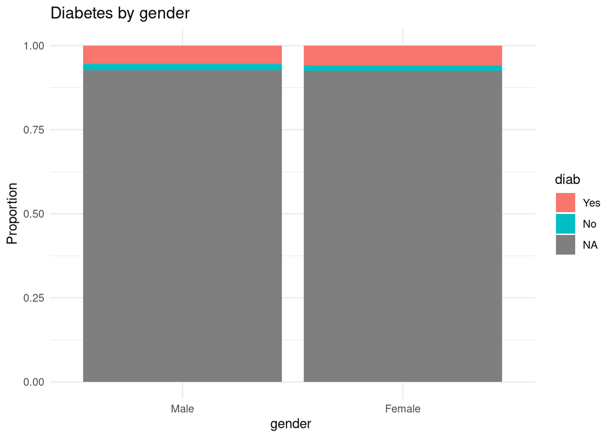

```r
# DIQ240 by Gender

ggplot(merged_data, aes(x = gender, fill = factor(diab)  )) +
  geom_bar(position = "fill") +
  theme_minimal() +
  labs(title = "Diabetes by gender ", x = "gender ", y = "Proportion", fill = "diab")
```

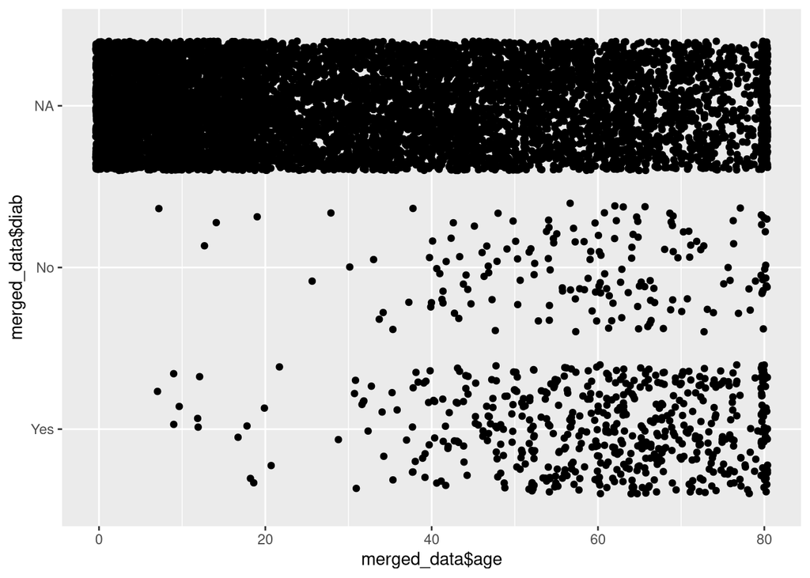

```r
ggplot(merged_data) +
    geom_point(aes(x = merged_data$age,  y = merged_data$diab),
               na.rm = TRUE,
               show.legend = TRUE,
               position = "jitter")
```

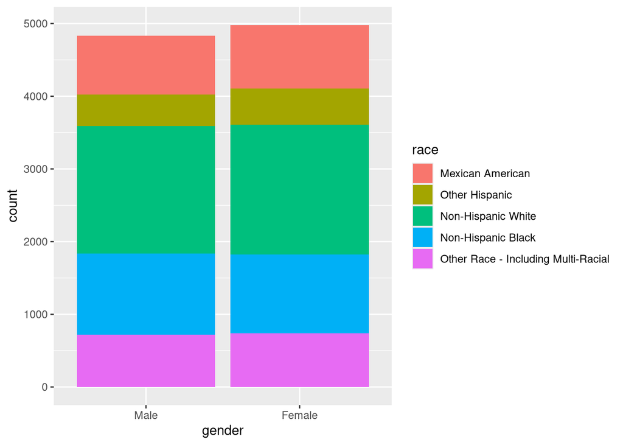

```r
ggplot(merged_data) +
    geom_bar(aes(x = gender, fill = race))
```

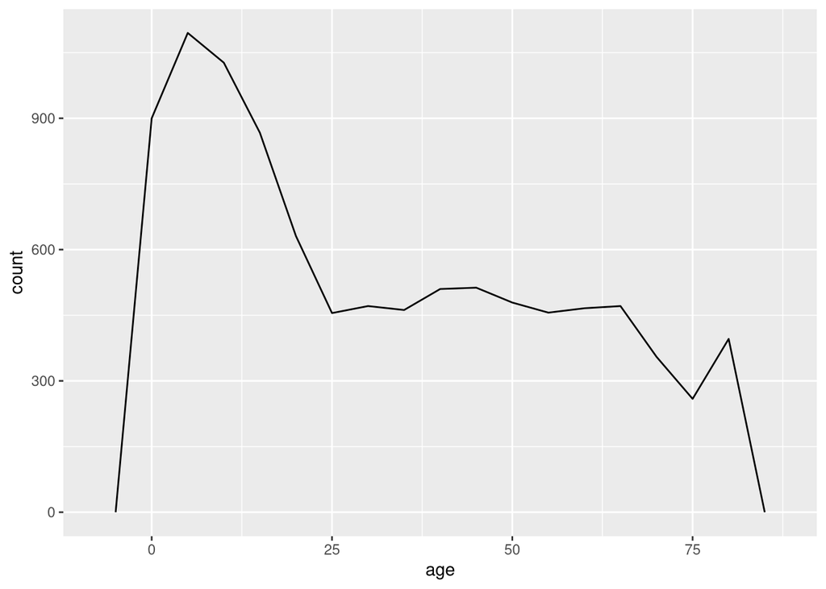

```r
ggplot(merged_data) +
    geom_freqpoly(aes(x = age), binwidth = 5, na.rm = TRUE)  # age distribution#
```

**Multiple logistic regression**

**Firth (penalized) regression**

Firth regression, a frquestist approach use Jeffreys prior for bias correction. It does not provide posterior and no sampling using MCMC (as in contrast to bayesian logisitic regression). Firth (penalized) regression was considered to handle quasi-separation, D’Angelo and Ran (2025).

```r
m_raw<- glm(diab ~ BMI_cat + age + gender + race,
                       family = binomial, data = merged_data)

 # quasi-complete separation #

m_raw
```

```
Call:  glm(formula = diab ~ BMI_cat + age + gender + race, family = binomial,
    data = merged_data)

Coefficients:
                            (Intercept)
                                 94.694
                      BMI_catOverweight
                                 50.968
                           BMI_catObese
                                -20.140
                                    age
                                 -9.984
                           genderFemale
                                 -4.011
                     raceOther Hispanic
                                -46.080
                 raceNon-Hispanic White
                                -50.787
                 raceNon-Hispanic Black
                                 73.273
raceOther Race - Including Multi-Racial
                                 13.094

Degrees of Freedom: 13 Total (i.e. Null);  5 Residual
  (9799 observations deleted due to missingness)
Null Deviance:      16.75
Residual Deviance: 2.259e-10    AIC: 18
```

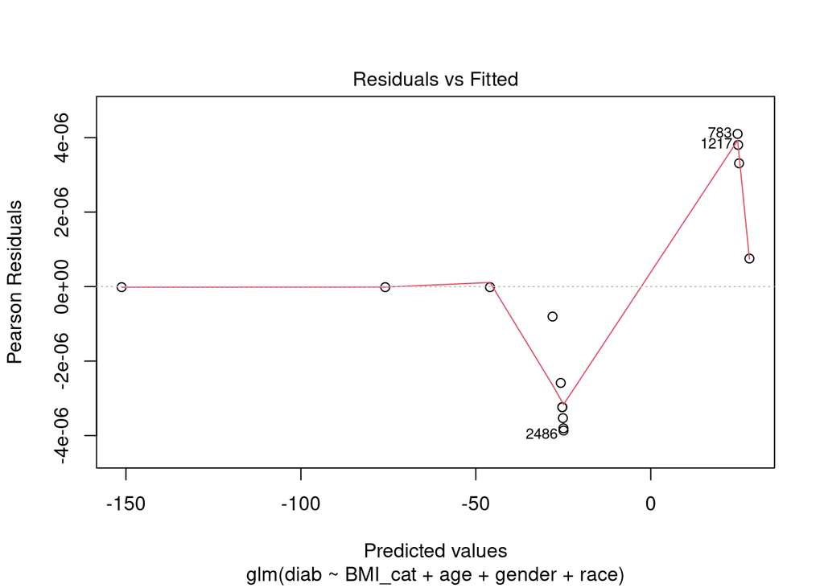

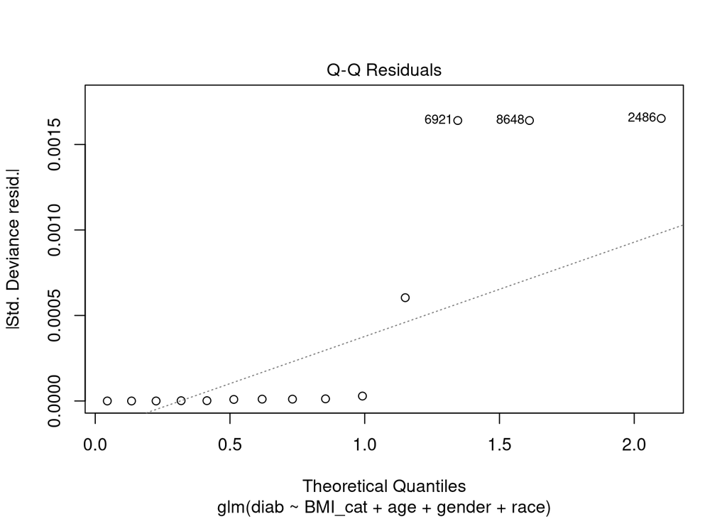

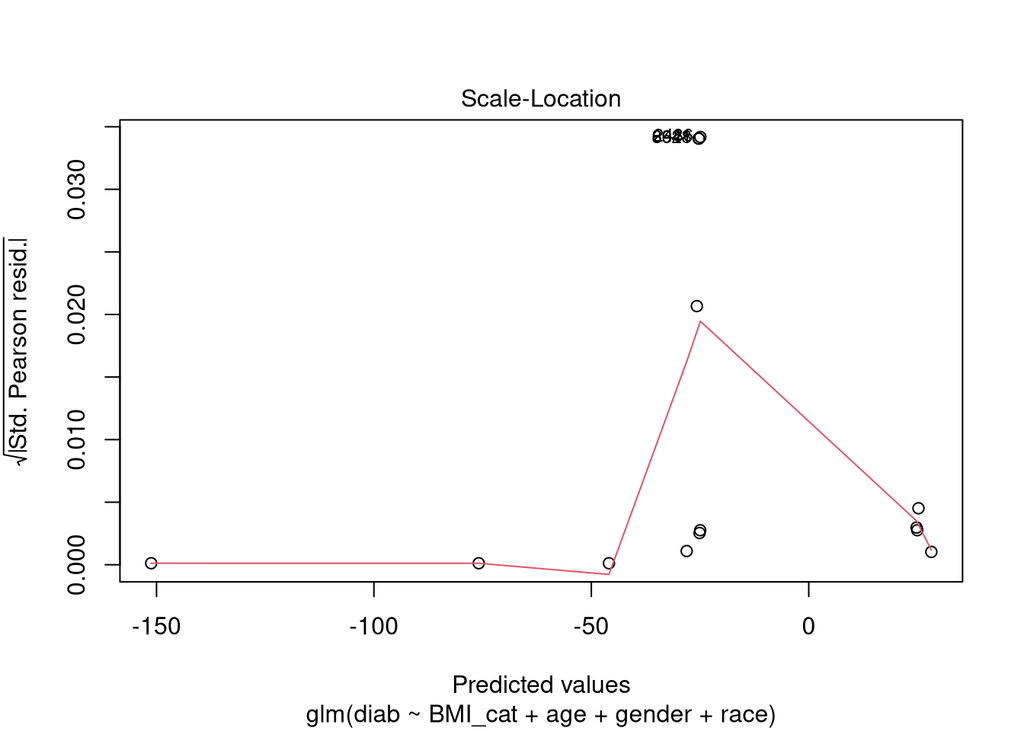

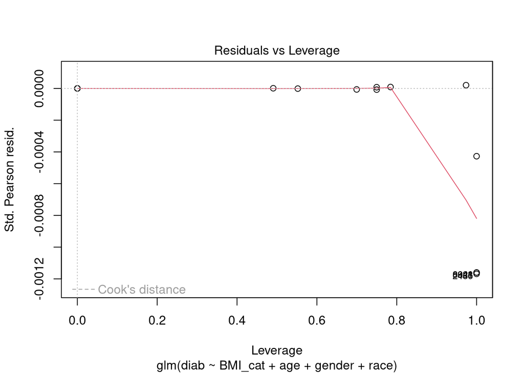

```r
plot(m_raw)
```

```r
head(na.action(m_raw))
```

```
1 2 3 4 5 6
1 2 3 4 5 6
```

```r
library(logistf) # penalized regression #

# Firth logistic regression
m_firth <- logistf(diab ~ BMI_cat + age + gender + race,
                   data = merged_data)

# Summary of results
summary(m_firth)
```

```
logistf(formula = diab ~ BMI_cat + age + gender + race, data = merged_data)

Model fitted by Penalized ML
Coefficients:
                                              coef  se(coef)  lower 0.95
(Intercept)                              2.2909182 2.0520292  -1.7059362
BMI_catOverweight                        2.5151817 1.9838969  -1.2146946
BMI_catObese                            -0.4519637 1.8778881  -5.4843160
age                                     -0.2545704 0.1911568  -1.4579663
genderFemale                            -2.1675543 2.0190594 -17.0316807
raceOther Hispanic                       0.9518795 1.9225099 -12.0194116
raceNon-Hispanic White                  -2.5671499 2.2189914 -21.6563170
raceNon-Hispanic Black                   3.3280688 2.2005227  -0.4678607
raceOther Race - Including Multi-Racial  1.3072954 2.0609641  -2.6483209
                                        upper 0.95      Chisq          p method
(Intercept)                             16.1697706 1.25690744 0.26223728      2
BMI_catOverweight                       21.9385716 1.68994830 0.19360778      2
BMI_catObese                             3.4687761 0.05538832 0.81393924      2
age                                      0.1148471 1.81192970 0.17827692      2
genderFemale                             5.9967059 0.69556457 0.40427809      2
raceOther Hispanic                      10.8617660 0.20246895 0.65273532      2
raceNon-Hispanic White                   1.6700624 1.36287409 0.24304000      2
raceNon-Hispanic Black                  25.3575974 2.86971841 0.09026066      2
raceOther Race - Including Multi-Racial 21.7820826 0.39215076 0.53117103      2

Method: 1-Wald, 2-Profile penalized log-likelihood, 3-None

Likelihood ratio test=6.066658 on 8 df, p=0.6397653, n=14
Wald test = 5.257182 on 8 df, p = 0.7297677
```

```r
# Odds ratios and 95% CIs
exp(coef(m_firth))
```

```
                            (Intercept)                       BMI_catOverweight
                             9.88400869                             12.36885607
                           BMI_catObese                                     age
                             0.63637730                              0.77524949
                           genderFemale                      raceOther Hispanic
                             0.11445720                              2.59057407
                 raceNon-Hispanic White                  raceNon-Hispanic Black
                             0.07675399                             27.88443973
raceOther Race - Including Multi-Racial
                             3.69616353
```

```r
exp(confint(m_firth))
```

```
                                           Lower 95%    Upper 95%
(Intercept)                             1.816023e-01 1.053033e+07
BMI_catOverweight                       2.968007e-01 3.371325e+09
BMI_catObese                            4.151374e-03 3.209744e+01
age                                     2.327090e-01 1.121702e+00
genderFemale                            4.010838e-08 4.021021e+02
raceOther Hispanic                      6.026094e-06 5.214408e+04
raceNon-Hispanic White                  3.933517e-10 5.312499e+00
raceNon-Hispanic Black                  6.263407e-01 1.029591e+11
raceOther Race - Including Multi-Racial 7.076994e-02 2.882958e+09
```

```python
import pandas as pd
```

## Unexpected reports, patterns or anomalies in raw **data**

**Linear regression and challenges of raw data**

- We found quasi-complete separation in the raw data (9799 observations dropped)
- Reduced sample size with less number of complete cases (n=14).
- The model is overfitted to this subset and cannot be generalized.
- Huge coefficients (e.g., 94, –50, 73) and the tiny residual deviance suggest perfect separation and sparse data in some categories with very few observations, resulted in imbalance in the outcome (very few cases of 0 or 1).
- Logistic regression cannot estimate stable coefficients when predictors perfectly classify the outcome.

**Firth regression (raw data) handled** quasi-separation with coefficients as finite, but the sample size was reduced (n= 14) where estimates are highly uncertain, wide confidence intervals → cannot make strong claims about predictor effects.

**Multivariate Imputation by Chained Equations (MICE)** Buuren and Groothuis-Oudshoorn (2011)

To avoid sample loss and potential bias in subsequent analyses, we considered multiple imputation (MI) as an alternative approach for the given raw dataset. Flatness of the density, heavy tails, non-zero peakedness, skewness and multimodality do not hamper the good performance of multiple imputation for the mean structure in samples n > 400, even for high percentages (75%) of missing data in one variable @Van Buuren and Van Buuren (2012). Multiple Imputation (MI) is a Bayesian Approach (use popular mice package in R) and adds sampling variability to the imputations. Iterative Imputation (MICE) imputes missing values of one variable at a time, using regression models based on the other variables in the dataset. This is a chain process, with each imputed variable becoming a predictor for the subsequent imputation and the entire process is repeated multiple times to create several complete datasets, each reflecting different possibilities for the missing data. Each variable is imputed using its own appropriate univariate regression model.

We performed Multivariate Imputation by Chained Equations (MICE) to handle missingness in the predictor (BMI) and in the response variable (diabetes status).

**Results from MICE:**

```r
## Multiple Imputation performed

library(mice)
library("VIM")

# Subset variables for imputation in analytic_data df

vars <- c("id","BMI_cat",  "age", "gender", "race", "SDMVPSU",  "SDMVSTRA", "WTMEC2YR", "diab"  )
analytic_data <- merged_data[, vars]

# Run mice to create 5 imputed datasets

imputed_data <- mice(
  analytic_data,
  m = 5,              # number of imputed datasets
  method = 'pmm',     # predictive mean matching
  seed = 123
)
str(imputed_data)
```

```
List of 23
 $ data           :'data.frame':    9813 obs. of  9 variables:
  ..$ id      : num [1:9813] 73557 73558 73559 73560 73561 ...
  ..$ BMI_cat : Factor w/ 4 levels "Underweight",..: NA NA NA 2 NA NA NA NA NA NA ...
  ..$ age     : num [1:9813] 69 54 72 9 73 56 0 61 56 65 ...
  ..$ gender  : Factor w/ 2 levels "Male","Female": 1 1 1 1 2 1 1 2 2 1 ...
  ..$ race    : Factor w/ 5 levels "Mexican American",..: 4 3 3 3 3 1 3 3 3 3 ...
  ..$ SDMVPSU : num [1:9813] 1 1 1 2 2 1 1 1 1 2 ...
  ..$ SDMVSTRA: num [1:9813] 112 108 109 109 116 111 105 114 112 112 ...
  ..$ WTMEC2YR: num [1:9813] 13481 24472 57193 55767 65542 ...
  ..$ diab    : Factor w/ 2 levels "Yes","No": 1 1 2 NA NA NA NA NA NA NA ...
 $ imp            :List of 9
  ..$ id      :'data.frame':    0 obs. of  5 variables:
  .. ..$ 1: logi(0)
  .. ..$ 2: logi(0)
  .. ..$ 3: logi(0)
  .. ..$ 4: logi(0)
  .. ..$ 5: logi(0)
  ..$ BMI_cat :'data.frame':    6290 obs. of  5 variables:
  .. ..$ 1: Factor w/ 4 levels "Underweight",..: 4 2 3 3 2 2 3 4 2 4 ...
  .. ..$ 2: Factor w/ 4 levels "Underweight",..: 2 4 4 4 4 2 2 3 4 2 ...
  .. ..$ 3: Factor w/ 4 levels "Underweight",..: 2 2 2 4 4 2 2 2 2 2 ...
  .. ..$ 4: Factor w/ 4 levels "Underweight",..: 4 2 2 2 4 2 3 2 2 1 ...
  .. ..$ 5: Factor w/ 4 levels "Underweight",..: 4 4 4 3 2 2 2 4 4 2 ...
  ..$ age     :'data.frame':    0 obs. of  5 variables:
  .. ..$ 1: logi(0)
  .. ..$ 2: logi(0)
  .. ..$ 3: logi(0)
  .. ..$ 4: logi(0)
  .. ..$ 5: logi(0)
  ..$ gender  :'data.frame':    0 obs. of  5 variables:
  .. ..$ 1: logi(0)
  .. ..$ 2: logi(0)
  .. ..$ 3: logi(0)
  .. ..$ 4: logi(0)
  .. ..$ 5: logi(0)
  ..$ race    :'data.frame':    0 obs. of  5 variables:
  .. ..$ 1: logi(0)
  .. ..$ 2: logi(0)
  .. ..$ 3: logi(0)
```

[output cut: 93 more lines]

```
 $ chainVar       : num [1:9, 1:5, 1:5] NA 0.699 NA NA NA ...
  ..- attr(*, "dimnames")=List of 3
  .. ..$ : chr [1:9] "id" "BMI_cat" "age" "gender" ...
  .. ..$ : chr [1:5] "1" "2" "3" "4" ...
  .. ..$ : chr [1:5] "Chain 1" "Chain 2" "Chain 3" "Chain 4" ...
 $ loggedEvents   :'data.frame':    11 obs. of  5 variables:
  ..$ it  : int [1:11] 1 1 2 2 2 3 3 3 4 5 ...
  ..$ im  : int [1:11] 2 4 3 4 5 2 4 5 4 1 ...
  ..$ dep : chr [1:11] "diab" "diab" "diab" "diab" ...
  ..$ meth: chr [1:11] "pmm" "pmm" "pmm" "pmm" ...
  ..$ out : chr [1:11] "BMI_catNormal weight" "BMI_catNormal weight" "BMI_catObese" "BMI_catNormal weight" ...
 $ version        :Classes 'package_version', 'numeric_version'  hidden list of 1
  ..$ : int [1:3] 3 18 0
 $ date           : Date[1:1], format: "2025-09-23"
 - attr(*, "class")= chr "mids"
```

```r
print(imputed_data)
```

```
Class: mids
Number of multiple imputations:  5
Imputation methods:
      id  BMI_cat      age   gender     race  SDMVPSU SDMVSTRA WTMEC2YR
      ""    "pmm"       ""       ""       ""       ""       ""       ""
    diab
   "pmm"
PredictorMatrix:
        id BMI_cat age gender race SDMVPSU SDMVSTRA WTMEC2YR diab
id       0       1   1      1    1       1        1        1    1
BMI_cat  1       0   1      1    1       1        1        1    1
age      1       1   0      1    1       1        1        1    1
gender   1       1   1      0    1       1        1        1    1
race     1       1   1      1    0       1        1        1    1
SDMVPSU  1       1   1      1    1       0        1        1    1
Number of logged events:  11
  it im  dep meth                  out
1  1  2 diab  pmm BMI_catNormal weight
2  1  4 diab  pmm BMI_catNormal weight
3  2  3 diab  pmm         BMI_catObese
4  2  4 diab  pmm BMI_catNormal weight
5  2  5 diab  pmm BMI_catNormal weight
6  3  2 diab  pmm BMI_catNormal weight
```

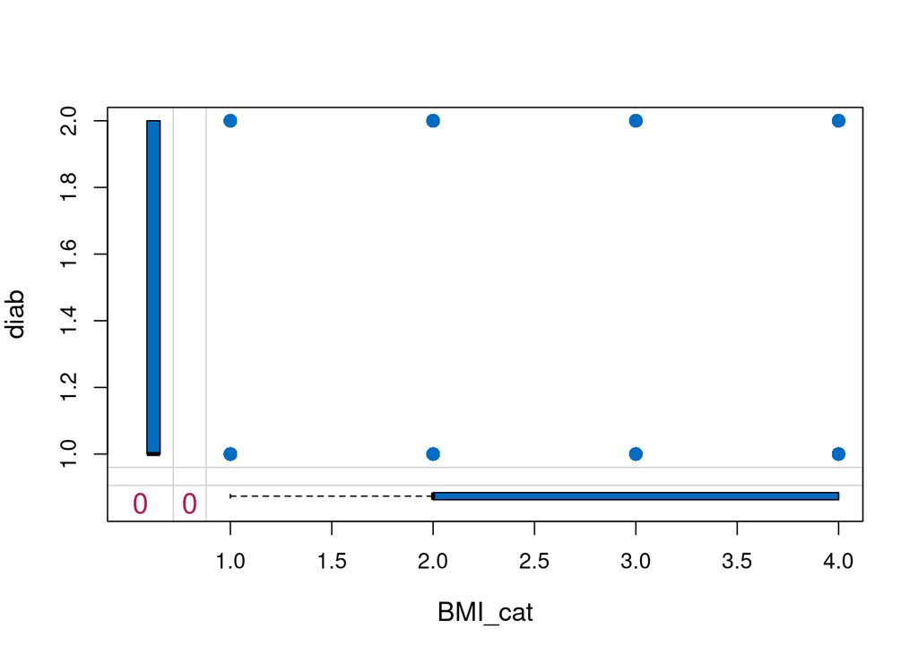

```r
# First imputed dataset

Imputed_data1 <- complete(imputed_data, 1)

marginplot(
  Imputed_data1[, c("BMI_cat", "diab")],
  col = mdc(1:2, trans = FALSE),
  cex = 1.2,
  cex.lab = 1.2,
  cex.numbers = 1.3,
  pch = 19
)
```

```r
# Checking missingness in imputed data

summary(Imputed_data1)
```

```
       id                 BMI_cat          age           gender
 Min.   :73557   Underweight  : 218   Min.   : 0.00   Male  :4831
 1st Qu.:76092   Normal weight:5107   1st Qu.:10.00   Female:4982
 Median :78643   Overweight   :1831   Median :27.00
 Mean   :78645   Obese        :2657   Mean   :31.63
 3rd Qu.:81191                        3rd Qu.:52.00
 Max.   :83731                        Max.   :80.00
                                  race         SDMVPSU         SDMVSTRA
 Mexican American                   :1685   Min.   :1.000   Min.   :104.0
 Other Hispanic                     : 930   1st Qu.:1.000   1st Qu.:107.0
 Non-Hispanic White                 :3538   Median :1.000   Median :111.0
 Non-Hispanic Black                 :2198   Mean   :1.483   Mean   :110.9
 Other Race - Including Multi-Racial:1462   3rd Qu.:2.000   3rd Qu.:115.0
                                            Max.   :2.000   Max.   :118.0
    WTMEC2YR       diab
 Min.   :  3748   Yes:7252
 1st Qu.: 13187   No :2561
 Median : 20965
 Mean   : 31713
 3rd Qu.: 37922
 Max.   :171395
```

```r
colSums(is.na(Imputed_data1))  # check total missing values
```

```
      id  BMI_cat      age   gender     race  SDMVPSU SDMVSTRA WTMEC2YR
       0        0        0        0        0        0        0        0
    diab
       0
```

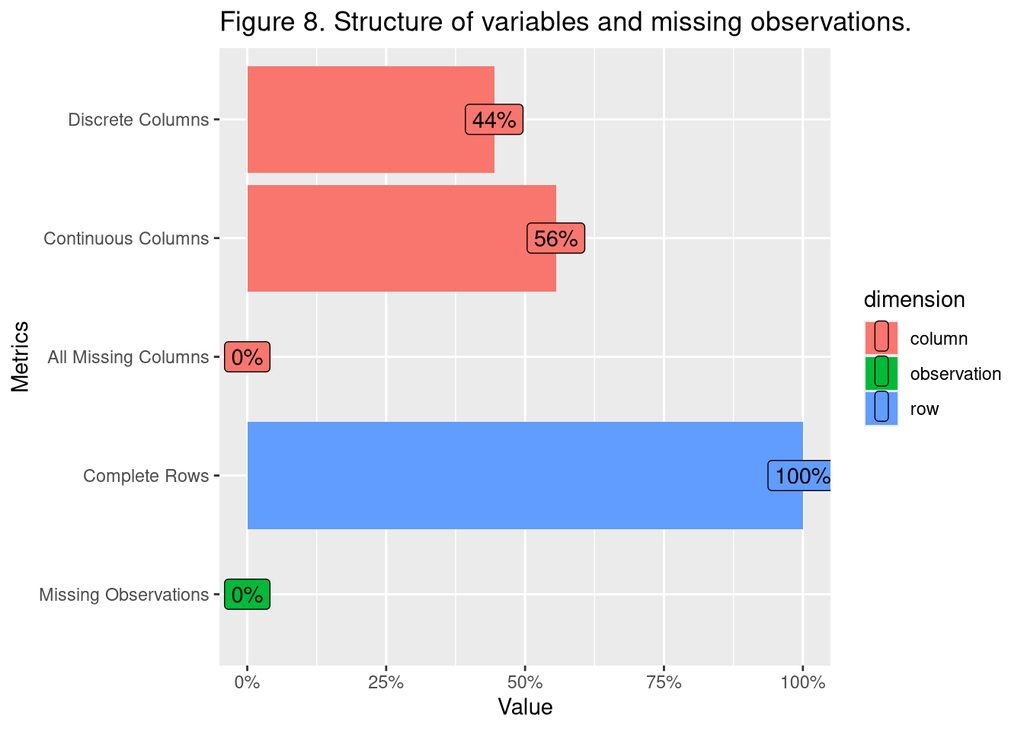

```r
plot_intro(Imputed_data1, title="Figure 8. Structure of variables and missing observations.")
```

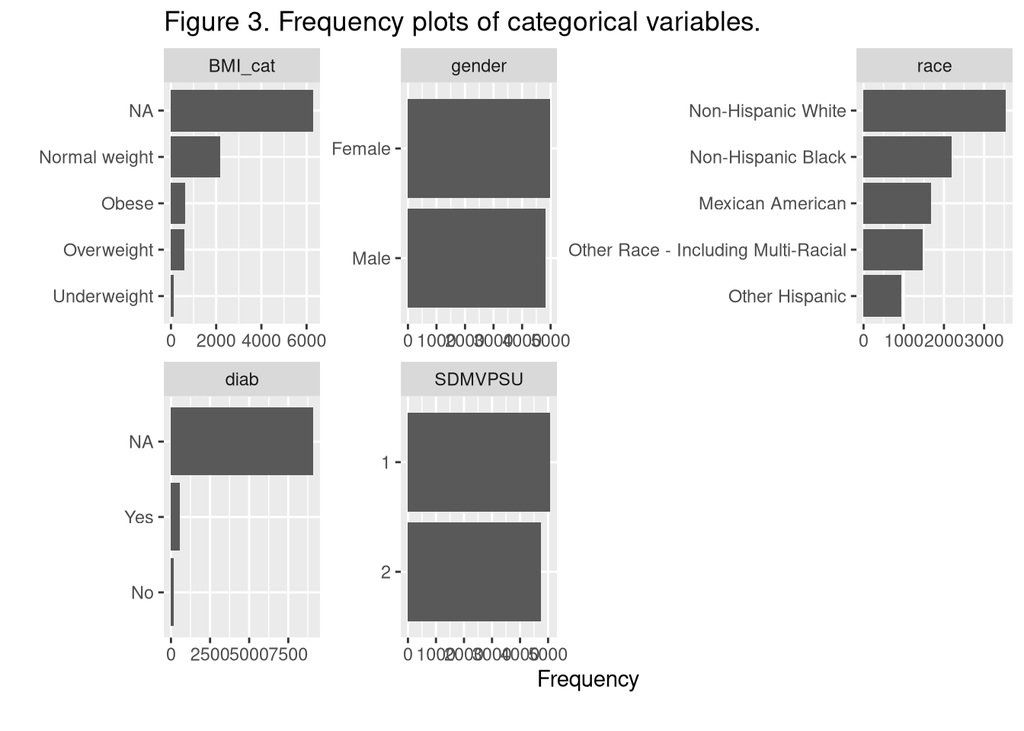

```r
plot_bar(merged_data, title = "Figure 3. Frequency plots of categorical variables.")
```